# Dissertation_analysis_template

2494935J

30/04/2020

##changes made caa 260520: - Changed section 2: converting NULL time to 00 - added in keys to several sections to make code more readable - removed section 4.1 converting NAs to median - added in section 4.5 to check usable values

#### 1. Load in packages and data

```r
library(tidyverse)
```

```r
library(ggplot2)
library(lubridate)
library(lavaan)
library(MVN)
library(semPlot)
library(broom)
library(car)
library(lsr)
library(Hmisc)
library(dplyr)

#loading in data
dat <- read_csv("Social-capital-and-sleep-quality-quests_2020-06-02.csv")
dat
```

```
## # A tibble: 12,680 x 13
##    session_id project_id quest_id user_id user_sex user_status user_age q_name
##         <dbl>      <dbl>    <dbl>   <dbl> <chr>    <chr>          <dbl> <chr>
##  1      35095        336     1899       1 female   admin           43.4 psqi_~
##  2      35095        336     1899       1 female   admin           43.4 psqi_~
##  3      35095        336     1899       1 female   admin           43.4 psqi_~
##  4      35095        336     1899       1 female   admin           43.4 psqi_~
##  5      35096        336     1899       1 female   admin           43.4 psqi_~
##  6      35096        336     1899       1 female   admin           43.4 psqi_~
##  7      35096        336     1899       1 female   admin           43.4 psqi_~
##  8      35096        336     1899       1 female   admin           43.4 psqi_~
##  9      35135        336     1899       3 female   super           43.4 psqi_~
## 10      35135        336     1899       3 female   super           43.4 psqi_~
## # ... with 12,670 more rows, and 5 more variables: q_id <dbl>, order <dbl>,
## #   dv <chr>, starttime <dttm>, endtime <dttm>
```

```r
dat %>% group_by(user_status) %>% summarise(n=n())
```

```
## # A tibble: 5 x 2
##   user_status     n
##   <chr>       <int>
## 1 admin          69
## 2 guest       11933
## 3 registered    319
## 4 student       334
## 5 super          25
```

```r
summary(dat$endtime)
```

```
##                  Min.               1st Qu.                Median
## "2020-04-22 10:39:03" "2020-05-02 13:51:18" "2020-05-03 07:58:44"
##                  Mean               3rd Qu.                  Max.
## "2020-05-04 21:58:30" "2020-05-04 21:54:02" "2020-05-30 20:11:29"
```

```r
dat <- dat %>% mutate(row = row_number())
dat
```

```
## # A tibble: 12,680 x 14
##    session_id project_id quest_id user_id user_sex user_status user_age q_name
##         <dbl>      <dbl>    <dbl>   <dbl> <chr>    <chr>          <dbl> <chr>
##  1      35095        336     1899       1 female   admin           43.4 psqi_~
##  2      35095        336     1899       1 female   admin           43.4 psqi_~
##  3      35095        336     1899       1 female   admin           43.4 psqi_~
##  4      35095        336     1899       1 female   admin           43.4 psqi_~
##  5      35096        336     1899       1 female   admin           43.4 psqi_~
##  6      35096        336     1899       1 female   admin           43.4 psqi_~
##  7      35096        336     1899       1 female   admin           43.4 psqi_~
##  8      35096        336     1899       1 female   admin           43.4 psqi_~
##  9      35135        336     1899       3 female   super           43.4 psqi_~
## 10      35135        336     1899       3 female   super           43.4 psqi_~
## # ... with 12,670 more rows, and 6 more variables: q_id <dbl>, order <dbl>,
## #   dv <chr>, starttime <dttm>, endtime <dttm>, row <int>
```

#### 2. Cleaning up the data

```
## # A tibble: 231 x 65
##    user_id user_sex user_age consent_answer DASS1_s DASS10_d DASS11_s DASS12_s
##      <dbl> <chr>       <dbl> <chr>            <int>    <int>    <int>    <int>
##  1   21248 female       23.2 1                    4        4        4        4
##  2   24796 female       42.8 1                    2        2        6        6
##  3   31889 female       22.8 1                    4        4        4        4
##  4   32291 <NA>         63   1                    2        0        2        2
##  5   32292 <NA>         29   1                    2        6        4        2
##  6   32293 <NA>         NA   1                    0        0        0        0
##  7   32294 female       24   1                    4       NA        4        4
##  8   32295 male         20   1                    2        2        0        2
##  9   32296 female       36   1                    0        2        2        2
## 10   32297 <NA>         24   1                    2        4        6        2
## # ... with 221 more rows, and 57 more variables: DASS13_d <int>,
## #   DASS14_s <int>, DASS15_a <int>, DASS16_d <int>, DASS17_d <int>,
## #   DASS18_s <int>, DASS19_a <int>, DASS2_a <int>, DASS20_a <int>,
## #   DASS21_d <int>, DASS3_d <int>, DASS4_a <int>, DASS5_d <int>, DASS6_s <int>,
## #   DASS7_a <int>, DASS8_s <int>, DASS9_a <int>, part_age <chr>,
## #   part_country <chr>, part_education <chr>, part_gender <chr>,
## #   part_home_time <chr>, part_marital_status <chr>, part_virus <chr>,
## #   psci_bonding_1 <int>, psci_bonding_2 <int>, psci_bonding_3 <int>,
## #   psci_bonding_4 <int>, psci_bonding_5 <int>, psci_bonding_6 <int>,
## #   psci_bonding_7 <int>, psci_bonding_8 <int>, psci_capital_10 <int>,
## #   psci_capital_11 <int>, psci_capital_12 <int>, psci_capital_13 <int>,
## #   psci_capital_14 <int>, psci_capital_15 <int>, psci_capital_16 <int>,
## #   psci_capital_9 <int>, psqi_5a <int>, psqi_5b <int>, psqi_5c <int>,
## #   psqi_5d <int>, psqi_5e <int>, psqi_5f <int>, psqi_5g <int>, psqi_5h <int>,
## #   psqi_5i <int>, psqi_5j <int>, psqi_6 <int>, psqi_7 <int>, psqi_8 <int>,
## #   psqi_hours_slept <chr>, psqi_hoursinbed1 <chr>, psqi_hoursinbed2 <chr>,
## #   psqi_sleep_latency1 <chr>
```

##checking demographics

```
## # A tibble: 231 x 66
##    user_id user_sex user_age consent_answer DASS1_s DASS10_d DASS11_s DASS12_s
##      <dbl> <chr>       <dbl> <chr>            <int>    <int>    <int>    <int>
##  1   21248 female       23.2 1                    4        4        4        4
##  2   24796 female       42.8 1                    2        2        6        6
##  3   31889 female       22.8 1                    4        4        4        4
##  4   32291 <NA>         63   1                    2        0        2        2
##  5   32292 <NA>         29   1                    2        6        4        2
##  6   32293 <NA>         NA   1                    0        0        0        0
##  7   32294 female       24   1                    4       NA        4        4
##  8   32295 male         20   1                    2        2        0        2
##  9   32296 female       36   1                    0        2        2        2
## 10   32297 <NA>         24   1                    2        4        6        2
## # ... with 221 more rows, and 58 more variables: DASS13_d <int>,
## #   DASS14_s <int>, DASS15_a <int>, DASS16_d <int>, DASS17_d <int>,
## #   DASS18_s <int>, DASS19_a <int>, DASS2_a <int>, DASS20_a <int>,
## #   DASS21_d <int>, DASS3_d <int>, DASS4_a <int>, DASS5_d <int>, DASS6_s <int>,
## #   DASS7_a <int>, DASS8_s <int>, DASS9_a <int>, part_age <chr>,
## #   part_country <chr>, part_education <chr>, part_gender <chr>,
## #   part_home_time <chr>, part_marital_status <chr>, part_virus <chr>,
## #   psci_bonding_1 <int>, psci_bonding_2 <int>, psci_bonding_3 <int>,
## #   psci_bonding_4 <int>, psci_bonding_5 <int>, psci_bonding_6 <int>,
## #   psci_bonding_7 <int>, psci_bonding_8 <int>, psci_capital_10 <int>,
## #   psci_capital_11 <int>, psci_capital_12 <int>, psci_capital_13 <int>,
## #   psci_capital_14 <int>, psci_capital_15 <int>, psci_capital_16 <int>,
## #   psci_capital_9 <int>, psqi_5a <int>, psqi_5b <int>, psqi_5c <int>,
## #   psqi_5d <int>, psqi_5e <int>, psqi_5f <int>, psqi_5g <int>, psqi_5h <int>,
## #   psqi_5i <int>, psqi_5j <int>, psqi_6 <int>, psqi_7 <int>, psqi_8 <int>,
## #   psqi_hours_slept <chr>, psqi_hoursinbed1 <chr>, psqi_hoursinbed2 <chr>,
## #   psqi_sleep_latency1 <chr>, rownumber <int>
```

```
## # A tibble: 13 x 4
## # Groups:   user_sex [4]
##    user_sex part_country     n mean.age
##    <chr>    <chr>        <int>    <dbl>
##  1 female   1               37     33.8
##  2 female   2               40     39.7
##  3 female   3                4     28.8
##  4 female   <NA>             2     27.5
##  5 male     1                9     38.1
##  6 male     2               59     27.4
##  7 male     3                5     29.6
##  8 male     <NA>             4     22.2
##  9 na       2                1     17
## 10 <NA>     1               12     NA
## 11 <NA>     2               50     NA
## 12 <NA>     3                2     33
## 13 <NA>     <NA>             6     24.7
```

```
## # A tibble: 4 x 3
##   part_country     n mean.age
##   <chr>        <int>    <dbl>
## 1 1               58     34.7
## 2 2              150     31.8
## 3 3               11     29.9
## 4 <NA>            12     24.3
```

#### 4. cleaning data for participants

## check guides for scoring method

#DASS: determine the scores for stress, depression, and anxiety multiplied by two #PSCI: summation of scores out of 80

#NB Scores on the DASS-21 will need to be multiplied by 2 to calculate the final score. Depression: normal = 0-9 mild = 10-13 moderate = 14-20 severe = 21-27 extremely severe = 28+ Anxiety: normal = 0-7 mild = 8-9 moderate = 10-14 severe = 15-19 extremely severe = 20+ Stress: normal = 0-14 mild = 15-18 moderate = 19-25 severe = 26-33 extremely severe = 34+

# DASS: variable names include suffix representing stress (e.g., DASS1_s), anxiety (e.g., DASS15_a), and depression (e.g., DASS10_d)

```
## # A tibble: 231 x 66
##    user_id user_sex user_age consent_answer DASS1_s DASS10_d DASS11_s DASS12_s
##      <dbl> <chr>       <dbl> <chr>            <int>    <int>    <int>    <int>
##  1   21248 female       23.2 1                    4        4        4        4
##  2   24796 female       42.8 1                    2        2        6        6
##  3   31889 female       22.8 1                    4        4        4        4
##  4   32291 <NA>         63   1                    2        0        2        2
##  5   32292 <NA>         29   1                    2        6        4        2
##  6   32293 <NA>         NA   1                    0        0        0        0
##  7   32294 female       24   1                    4       NA        4        4
##  8   32295 male         20   1                    2        2        0        2
##  9   32296 female       36   1                    0        2        2        2
## 10   32297 <NA>         24   1                    2        4        6        2
## # ... with 221 more rows, and 58 more variables: DASS13_d <int>,
## #   DASS14_s <int>, DASS15_a <int>, DASS16_d <int>, DASS17_d <int>,
## #   DASS18_s <int>, DASS19_a <int>, DASS2_a <int>, DASS20_a <int>,
## #   DASS21_d <int>, DASS3_d <int>, DASS4_a <int>, DASS5_d <int>, DASS6_s <int>,
## #   DASS7_a <int>, DASS8_s <int>, DASS9_a <int>, part_age <chr>,
## #   part_country <chr>, part_education <chr>, part_gender <chr>,
## #   part_home_time <chr>, part_marital_status <chr>, part_virus <chr>,
## #   psci_bonding_1 <int>, psci_bonding_2 <int>, psci_bonding_3 <int>,
## #   psci_bonding_4 <int>, psci_bonding_5 <int>, psci_bonding_6 <int>,
## #   psci_bonding_7 <int>, psci_bonding_8 <int>, psci_capital_10 <int>,
## #   psci_capital_11 <int>, psci_capital_12 <int>, psci_capital_13 <int>,
## #   psci_capital_14 <int>, psci_capital_15 <int>, psci_capital_16 <int>,
## #   psci_capital_9 <int>, psqi_5a <int>, psqi_5b <int>, psqi_5c <int>,
## #   psqi_5d <int>, psqi_5e <int>, psqi_5f <int>, psqi_5g <int>, psqi_5h <int>,
## #   psqi_5i <int>, psqi_5j <int>, psqi_6 <int>, psqi_7 <int>, psqi_8 <int>,
## #   psqi_hours_slept <chr>, psqi_hoursinbed1 <chr>, psqi_hoursinbed2 <chr>,
## #   psqi_sleep_latency1 <chr>, rownumber <int>
```

```
## # A tibble: 231 x 51
##    user_id user_sex user_age consent_answer DASS1_s DASS10_d DASS11_s DASS12_s
##      <dbl> <chr>       <dbl> <chr>            <int>    <int>    <int>    <int>
##  1   21248 female       23.2 1                    4        4        4        4
##  2   24796 female       42.8 1                    2        2        6        6
##  3   31889 female       22.8 1                    4        4        4        4
##  4   32291 <NA>         63   1                    2        0        2        2
##  5   32292 <NA>         29   1                    2        6        4        2
##  6   32293 <NA>         NA   1                    0        0        0        0
##  7   32294 female       24   1                    4       NA        4        4
##  8   32295 male         20   1                    2        2        0        2
##  9   32296 female       36   1                    0        2        2        2
## 10   32297 <NA>         24   1                    2        4        6        2
## # ... with 221 more rows, and 43 more variables: DASS13_d <int>,
## #   DASS14_s <int>, DASS15_a <int>, DASS16_d <int>, DASS17_d <int>,
## #   DASS18_s <int>, DASS19_a <int>, DASS2_a <int>, DASS20_a <int>,
## #   DASS21_d <int>, DASS3_d <int>, DASS4_a <int>, DASS5_d <int>, DASS6_s <int>,
## #   DASS7_a <int>, DASS8_s <int>, DASS9_a <int>, part_age <chr>,
## #   part_country <chr>, part_education <chr>, part_gender <chr>,
## #   part_home_time <chr>, part_marital_status <chr>, part_virus <chr>,
## #   psqi_5a <int>, psqi_5b <int>, psqi_5c <int>, psqi_5d <int>, psqi_5e <int>,
## #   psqi_5f <int>, psqi_5g <int>, psqi_5h <int>, psqi_5i <int>, psqi_5j <int>,
## #   psqi_6 <int>, psqi_7 <int>, psqi_8 <int>, psqi_hours_slept <chr>,
## #   psqi_hoursinbed1 <chr>, psqi_hoursinbed2 <chr>, psqi_sleep_latency1 <chr>,
## #   rownumber <int>, PSCI_score <int>
```

```
## # A tibble: 4 x 2
##   part_country  mean
##   <chr>        <dbl>
## 1 1             28.7
## 2 2             22.3
## 3 3             34.2
## 4 <NA>          40
```

####4.1 refining PSQI score

```
## # A tibble: 231 x 33
##    user_id user_sex user_age consent_answer part_age part_country part_education
##      <dbl> <chr>       <dbl> <chr>          <chr>    <chr>        <chr>
##  1   21248 female       23.2 1              23       1            4
##  2   24796 female       42.8 1              42       1            5
##  3   31889 female       22.8 1              22       1            4
##  4   32291 <NA>         63   1              63       2            4
##  5   32292 <NA>         29   1              29       2            4
##  6   32293 <NA>         NA   1              21       2            3
##  7   32294 female       24   1              24       1            4
##  8   32295 male         20   1              20       2            3
##  9   32296 female       36   1              36       2            4
## 10   32297 <NA>         24   1              24       2            2
## # ... with 221 more rows, and 26 more variables: part_gender <chr>,
## #   part_home_time <chr>, part_marital_status <chr>, part_virus <chr>,
## #   psqi_5a <int>, psqi_5b <int>, psqi_5c <int>, psqi_5d <int>, psqi_5e <int>,
## #   psqi_5f <int>, psqi_5g <int>, psqi_5h <int>, psqi_5i <int>, psqi_5j <int>,
## #   psqi_6 <int>, psqi_7 <int>, psqi_8 <int>, psqi_hours_slept <chr>,
## #   psqi_hoursinbed1 <chr>, psqi_hoursinbed2 <chr>, psqi_sleep_latency1 <chr>,
## #   rownumber <int>, PSCI_score <int>, stress_score <dbl>, anxiety_score <dbl>,
## #   depression_score <dbl>
```

```
## # A tibble: 231 x 18
##    user_id psqi_5a psqi_5b psqi_5c psqi_5d psqi_5e psqi_5f psqi_5g psqi_5h
##      <dbl>   <int>   <int>   <int>   <int>   <int>   <int>   <int>   <int>
##  1   21248       3       1       0       0       0       0       1       1
##  2   24796       3       3       3       0       0       1       1       0
##  3   31889       2       3       3       2       0       1       1       2
##  4   32291       1       2       2       0       0       0       0       0
##  5   32292       0       1       1       2       3       0       3       1
##  6   32293       2       0       1       0       0       0       3       0
##  7   32294       3       2       0       0       0       0       0       1
##  8   32295       3       2       1       2       0       2       2       0
##  9   32296       3       0       0       0       0       0       0       0
## 10   32297       1       1       0       0       0       0       0       2
## # ... with 221 more rows, and 9 more variables: psqi_5i <int>, psqi_5j <int>,
## #   psqi_6 <int>, psqi_7 <int>, psqi_8 <int>, psqi_hours_slept <chr>,
## #   psqi_hoursinbed1 <chr>, psqi_hoursinbed2 <chr>, psqi_sleep_latency1 <chr>
```

####4.2 calculating PSQI score

see pitsburgh assessment for scoring the PSQI

```
## # A tibble: 231 x 10
##    user_id psqi_hours_slept comp2 comp3 hours_in_bed_abs sleep_eff comp4 comp5
##      <dbl>            <dbl> <dbl> <dbl>            <dbl>     <dbl> <dbl> <dbl>
##  1   21248              8       3     0             9.5       84.2     1     1
##  2   24796              9       3     0            13.3       67.5     2     2
##  3   31889             NA      NA    NA            NA         NA      NA     2
##  4   32291              7       1     0             8         87.5     0     1
##  5   32292              6       0     1             5.5      109.      0     2
##  6   32293              9       2     0             8        112.      0     1
##  7   32294             10       3     0            10        100       0     1
##  8   32295              6.5     3     1             7.5       86.7     0     1
##  9   32296              7       3     0             8.25      84.8     1     0
## 10   32297              4       1     3             5         80       1     1
## # ... with 221 more rows, and 2 more variables: comp6 <int>, comp7 <dbl>
```

```
## # A tibble: 64 x 10
##    user_id psqi_hours_slept comp2 comp3 hours_in_bed_abs sleep_eff comp4 comp5
##      <dbl>            <dbl> <dbl> <dbl>            <dbl>     <dbl> <dbl> <dbl>
##  1   31889               NA    NA    NA             NA        NA      NA     2
##  2   32310               NA    NA    NA             NA        NA      NA    NA
##  3   32314               NA    NA    NA             NA        NA      NA    NA
##  4   32318               NA    NA    NA             NA        NA      NA    NA
##  5   32319               NA    NA    NA             NA        NA      NA    NA
##  6   32322               NA    NA    NA             NA        NA      NA    NA
##  7   32325               NA    NA    NA             NA        NA      NA    NA
##  8   32331               NA    NA    NA             NA        NA      NA    NA
##  9   32334                7     0     0              7.5      93.3     0    NA
## 10   32339                5     3     2              6        83.3     1    NA
## # ... with 54 more rows, and 2 more variables: comp6 <int>, comp7 <dbl>
```

##4.3 descriptives for PSQI

```
## # A tibble: 1 x 4
##    mean   s.d   max   min
##   <dbl> <dbl> <dbl> <dbl>
## 1  5.77  2.98    15     1
```

##4.4 Joining back to data

```
## # A tibble: 231 x 15
##    user_id user_age consent_answer part_country part_education part_gender
##      <dbl>    <dbl>          <dbl> <chr>        <chr>          <chr>
##  1   21248     23.2              1 1            4              2
##  2   24796     42.8              1 1            5              2
##  3   31889     22.8              1 1            4              2
##  4   32291     63                1 2            4              2
##  5   32292     29                1 2            4              1
##  6   32293     NA                1 2            3              1
##  7   32294     24                1 1            4              2
##  8   32295     20                1 2            3              1
##  9   32296     36                1 2            4              2
## 10   32297     24                1 2            2              1
## # ... with 221 more rows, and 9 more variables: part_home_time <chr>,
## #   part_marital_status <chr>, part_virus <chr>, rownumber <int>,
## #   PSCI_score <int>, stress_score <dbl>, anxiety_score <dbl>,
## #   depression_score <dbl>, psqi_score <dbl>
```

##4.5 checking NA values for each var

as of 310520, only 159 values usable

```
## # A tibble: 231 x 15
##    user_id user_age consent_answer part_country part_education part_gender
##      <dbl>    <dbl>          <dbl> <chr>        <chr>          <chr>
##  1   21248     23.2              1 1            4              2
##  2   24796     42.8              1 1            5              2
##  3   31889     22.8              1 1            4              2
##  4   32291     63                1 2            4              2
##  5   32292     29                1 2            4              1
##  6   32293     NA                1 2            3              1
##  7   32294     24                1 1            4              2
##  8   32295     20                1 2            3              1
##  9   32296     36                1 2            4              2
## 10   32297     24                1 2            2              1
## # ... with 221 more rows, and 9 more variables: part_home_time <chr>,
## #   part_marital_status <chr>, part_virus <chr>, rownumber <int>,
## #   PSCI_score <int>, stress_score <dbl>, anxiety_score <dbl>,
## #   depression_score <dbl>, psqi_score <dbl>
```

```
## [1] "tbl_df"     "tbl"        "data.frame"
```

#5. descriptives of participants

```r
dat_final
```

```
## # A tibble: 231 x 15
##    user_id user_age consent_answer part_country part_education part_gender
##      <dbl>    <dbl>          <dbl> <chr>        <chr>          <chr>
##  1   21248     23.2              1 1            4              2
##  2   24796     42.8              1 1            5              2
##  3   31889     22.8              1 1            4              2
##  4   32291     63                1 2            4              2
##  5   32292     29                1 2            4              1
##  6   32293     NA                1 2            3              1
##  7   32294     24                1 1            4              2
##  8   32295     20                1 2            3              1
##  9   32296     36                1 2            4              2
## 10   32297     24                1 2            2              1
## # ... with 221 more rows, and 9 more variables: part_home_time <chr>,
## #   part_marital_status <chr>, part_virus <chr>, rownumber <int>,
## #   PSCI_score <int>, stress_score <dbl>, anxiety_score <dbl>,
## #   depression_score <dbl>, psqi_score <dbl>
```

#6. final values used

```r
dat_final1 <- anti_join(dat_final, missing_scores)
dat_final1
```

```
## # A tibble: 159 x 15
##    user_id user_age consent_answer part_country part_education part_gender
##      <dbl>    <dbl>          <dbl> <chr>        <chr>          <chr>
##  1   21248     23.2              1 1            4              2
##  2   24796     42.8              1 1            5              2
##  3   32291     63                1 2            4              2
##  4   32292     29                1 2            4              1
##  5   32293     NA                1 2            3              1
##  6   32295     20                1 2            3              1
##  7   32296     36                1 2            4              2
##  8   32297     24                1 2            2              1
##  9   32298     27                1 1            4              2
## 10   32299     29                1 2            2              1
## # ... with 149 more rows, and 9 more variables: part_home_time <chr>,
## #   part_marital_status <chr>, part_virus <chr>, rownumber <int>,
## #   PSCI_score <int>, stress_score <dbl>, anxiety_score <dbl>,
## #   depression_score <dbl>, psqi_score <dbl>
```

#7. Evaluation correlation

```r
x_vars <- dat_final1[,c("PSCI_score","stress_score","anxiety_score","depression_score", "psqi_score")]
x_vars2 <- as.data.frame(x_vars)
correlate(x_vars2,
          test = T,
          corr.method = "pearson",
          p.adjust.method = "holm")
```

```
##
## CORRELATIONS
## ============
## - correlation type:  pearson
## - correlations shown only when both variables are numeric
##
##                  PSCI_score    stress_score    anxiety_score
## PSCI_score                .          -0.065           -0.098
## stress_score         -0.065               .            0.744***
## anxiety_score        -0.098           0.744***             .
## depression_score     -0.174           0.727***         0.664***
## psqi_score           -0.019           0.601***         0.561***
##                  depression_score    psqi_score
## PSCI_score                 -0.174        -0.019
## stress_score                0.727***      0.601***
## anxiety_score               0.664***      0.561***
## depression_score                .         0.508***
## psqi_score                  0.508***          .
##
## ---
## Signif. codes: . = p < .1, * = p<.05, ** = p<.01, *** = p<.001
##
##
## p-VALUES
## ========
## - total number of tests run:  10
## - correction for multiple testing:  holm
##
##                  PSCI_score stress_score anxiety_score depression_score
## PSCI_score                .        0.835         0.656            0.114
## stress_score          0.835            .         0.000            0.000
## anxiety_score         0.656        0.000             .            0.000
## depression_score      0.114        0.000         0.000                .
## psqi_score            0.835        0.000         0.000            0.000
##                  psqi_score
## PSCI_score            0.835
## stress_score          0.000
## anxiety_score         0.000
## depression_score      0.000
## psqi_score                .
##
##
## SAMPLE SIZES
## ============
##
##                  PSCI_score stress_score anxiety_score depression_score
## PSCI_score              159          159           159              159
## stress_score            159          159           159              159
## anxiety_score           159          159           159              159
## depression_score        159          159           159              159
## psqi_score              159          159           159              159
##                  psqi_score
## PSCI_score              159
## stress_score            159
## anxiety_score           159
## depression_score        159
## psqi_score              159
```

#8. Path analysis

##8.1 checking the assumptions:

```r
##checked using MVN package:
#checking normality for individual scores
mvn(x_vars)
```

```
## $multivariateNormality
##              Test        Statistic              p value Result
## 1 Mardia Skewness  130.58002657307 6.03801034065097e-13     NO
## 2 Mardia Kurtosis 2.98160341979529  0.00286743178648652     NO
## 3             MVN             <NA>                 <NA>     NO
##
## $univariateNormality
##           Test         Variable Statistic   p value Normality
## 1 Shapiro-Wilk    PSCI_score       0.9721  0.0026      NO
## 2 Shapiro-Wilk   stress_score      0.9468  <0.001      NO
## 3 Shapiro-Wilk  anxiety_score      0.8500  <0.001      NO
## 4 Shapiro-Wilk depression_score    0.9247  <0.001      NO
## 5 Shapiro-Wilk    psqi_score       0.9413  <0.001      NO
##
## $Descriptives
##                    n      Mean   Std.Dev Median Min Max 25th 75th       Skew
## PSCI_score       159 47.616352  9.337415     48  17  77   42   54 -0.5214751
## stress_score     159 24.729560 18.538255     24   0  72    8   36  0.3780093
## anxiety_score    159 12.805031 13.729981      8   0  64    0   20  1.2221546
## depression_score 159 25.056604 20.874321     20   0  84    8   40  0.6540294
## psqi_score       159  5.761006  3.030351      5   1  15    3    8  0.7151918
##                     Kurtosis
## PSCI_score        1.00160096
## stress_score     -0.69096440
## anxiety_score     1.02690149
## depression_score -0.47015878
## psqi_score        0.01274812
```

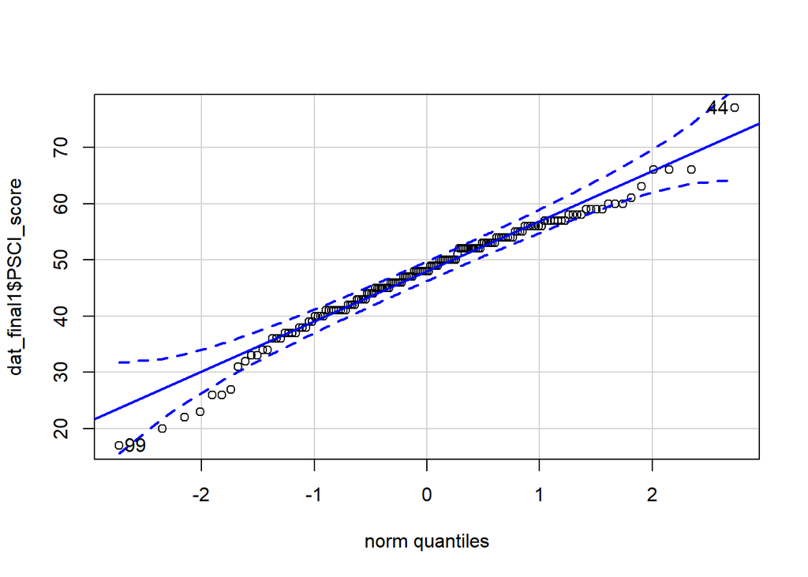

```
## [1] 99 44
```

```r
##test for PSCI score
qqPlot(x=dat_final1$PSCI_score)
```

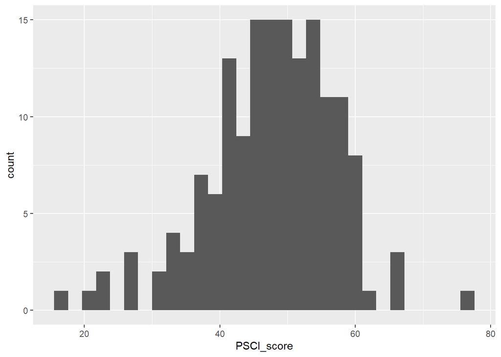

```r
ggplot(data = dat_final1, aes(x = PSCI_score)) +
  geom_histogram()
```

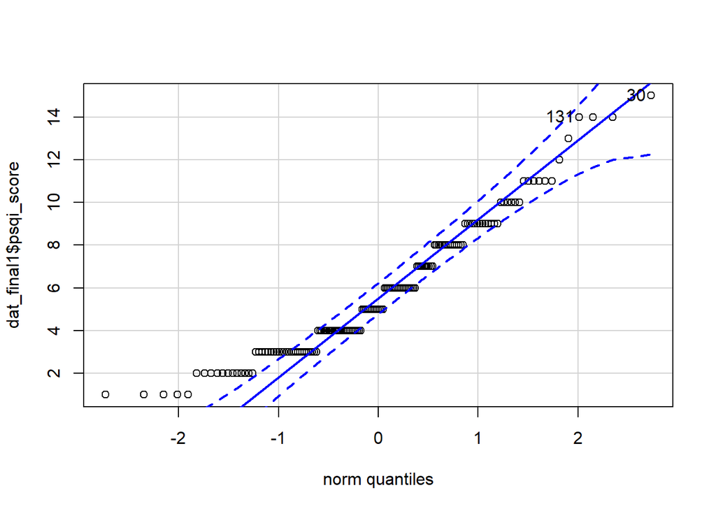

```
## [1]  30 131
```

```r
##test for psqi_score
qqPlot(x=dat_final1$psqi_score)
```

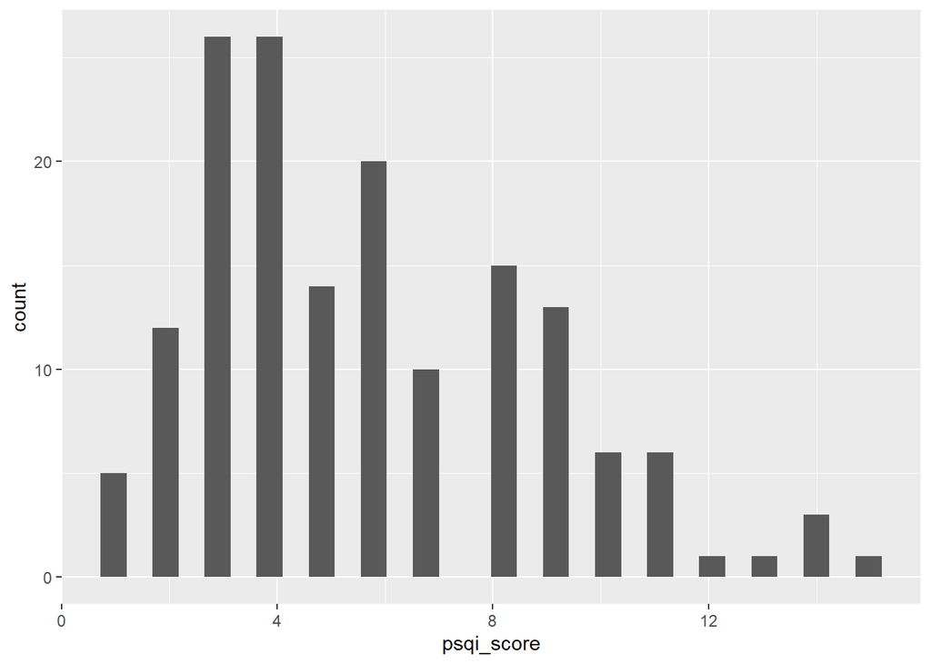

```r
ggplot(data = dat_final1, aes(x = psqi_score)) +
  geom_histogram()
```

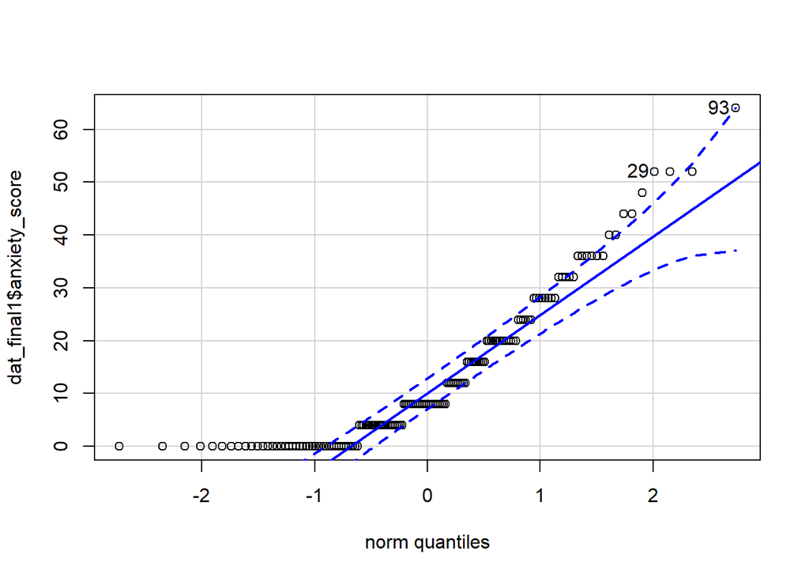

```
## [1] 93 29
```

```r
##test for anxiety_score
qqPlot(x=dat_final1$anxiety_score)
```

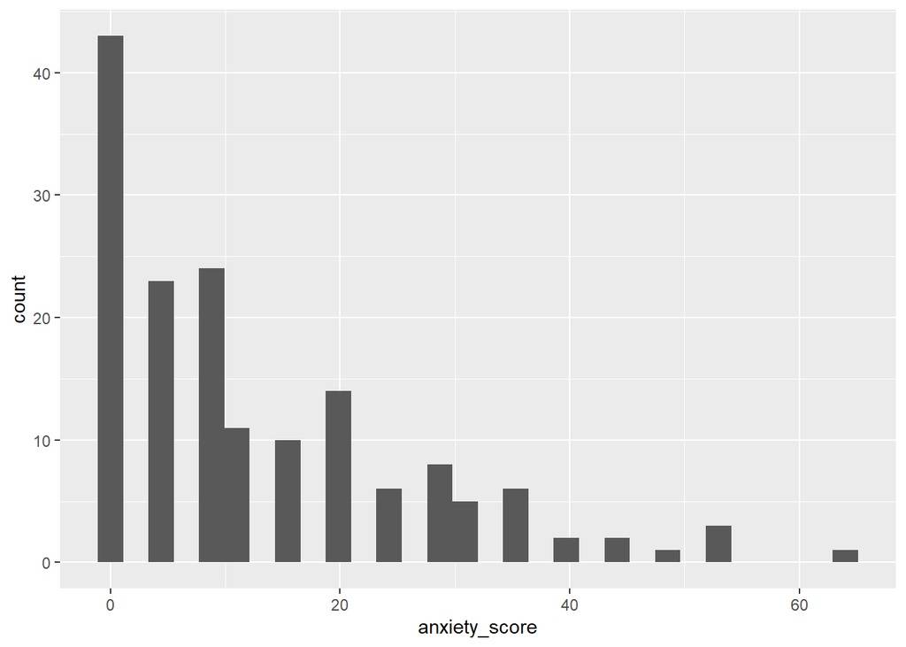

```r
ggplot(data = dat_final1, aes(x = anxiety_score)) +
  geom_histogram()
```

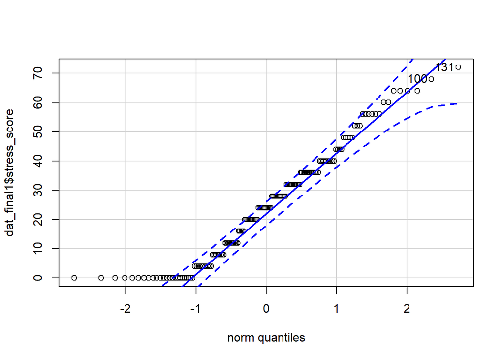

```
## [1] 131 100
```

```r
##test for stress_score
qqPlot(x=dat_final1$stress_score)
```

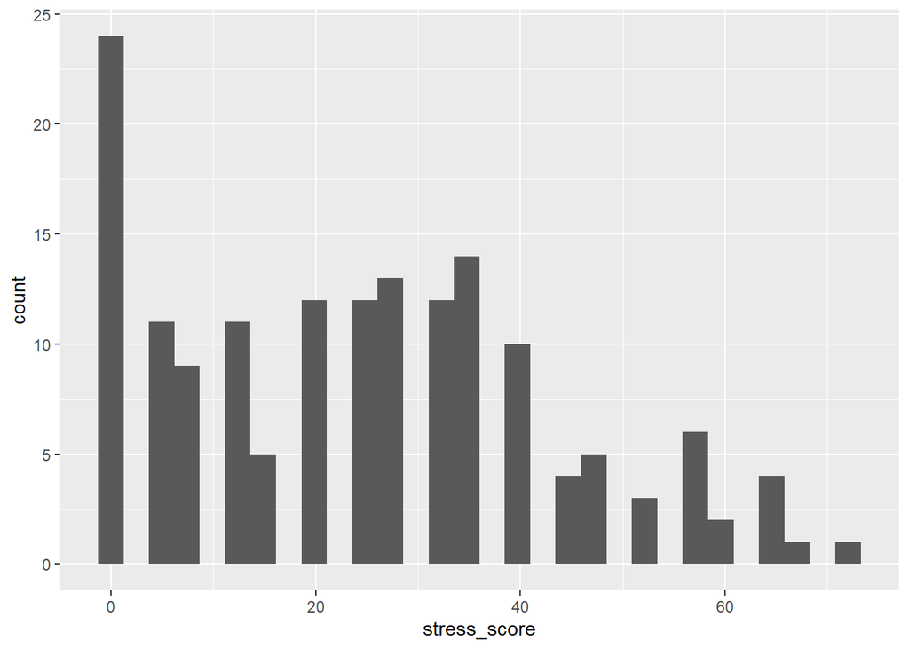

```r
ggplot(data = dat_final1, aes(x = stress_score)) +
  geom_histogram()
```

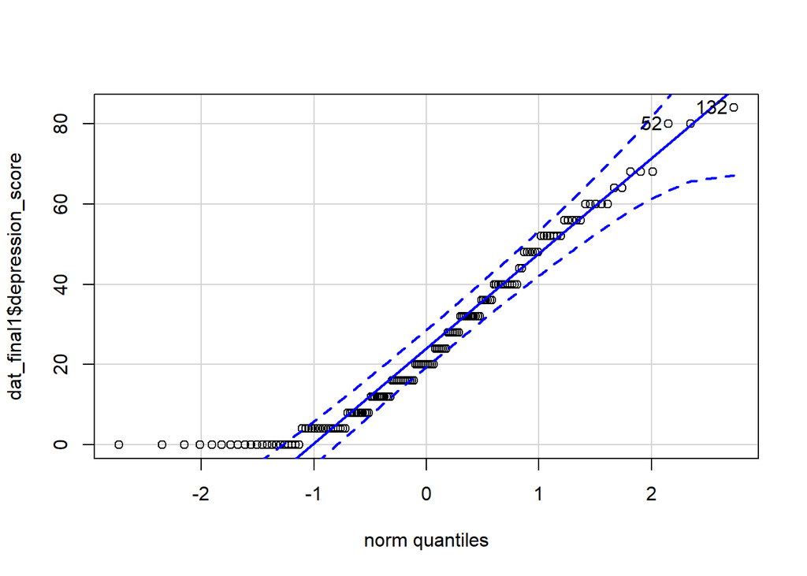

```
## [1] 132  52
```

```r
##test for depression_score
qqPlot(x=dat_final1$depression_score)
```

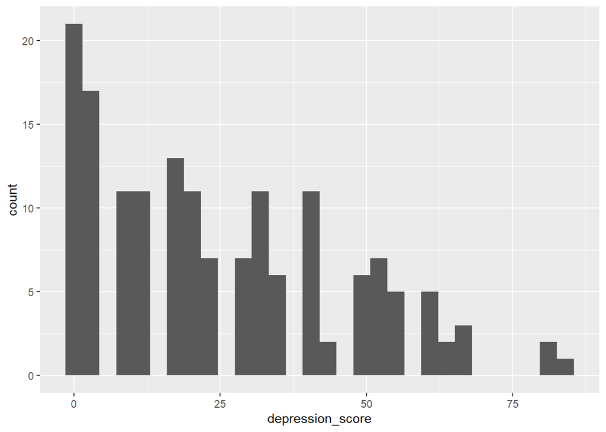

```r
ggplot(data = dat_final1, aes(x = depression_score)) +
  geom_histogram()
```

##8.1 model1 note: Higher PSQI scores indicate worse sleep quality.

```r
dat_final1
```

```
## # A tibble: 159 x 15
##    user_id user_age consent_answer part_country part_education part_gender
##      <dbl>    <dbl>          <dbl> <chr>        <chr>          <chr>
##  1   21248     23.2              1 1            4              2
##  2   24796     42.8              1 1            5              2
##  3   32291     63                1 2            4              2
##  4   32292     29                1 2            4              1
##  5   32293     NA                1 2            3              1
##  6   32295     20                1 2            3              1
##  7   32296     36                1 2            4              2
##  8   32297     24                1 2            2              1
##  9   32298     27                1 1            4              2
## 10   32299     29                1 2            2              1
## # ... with 149 more rows, and 9 more variables: part_home_time <chr>,
## #   part_marital_status <chr>, part_virus <chr>, rownumber <int>,
## #   PSCI_score <int>, stress_score <dbl>, anxiety_score <dbl>,
## #   depression_score <dbl>, psqi_score <dbl>
```

```r
model1 <- '
negative_affect =~ stress_score + anxiety_score + depression_score

## Regressions with Parameter Names
negative_affect~ a1*PSCI_score
psqi_score~b1*negative_affect
psqi_score~c1*PSCI_score

## Indirect Effects
PSQI_negative := a1*b1
# Total effects
total := c1 + (a1*b1)
'


fit1 <- sem(model1,
            data=dat_final1)
summary(fit1,fit.measures=TRUE, standardized=TRUE) #P-value of model at 0.297
```

```
## lavaan 0.6-6 ended normally after 81 iterations
##
##   Estimator                                         ML
##   Optimization method                           NLMINB
##   Number of free parameters                         10
##
##   Number of observations                           159
##
## Model Test User Model:
##
##   Test statistic                                 4.903
##   Degrees of freedom                                 4
##   P-value (Chi-square)                           0.297
##
## Model Test Baseline Model:
##
##   Test statistic                               346.210
##   Degrees of freedom                                10
##   P-value                                        0.000
##
## User Model versus Baseline Model:
##
##   Comparative Fit Index (CFI)                    0.997
##   Tucker-Lewis Index (TLI)                       0.993
##
## Loglikelihood and Information Criteria:
##
##   Loglikelihood user model (H0)              -2269.957
##   Loglikelihood unrestricted model (H1)      -2267.506
##
##   Akaike (AIC)                                4559.915
##   Bayesian (BIC)                              4590.604
##   Sample-size adjusted Bayesian (BIC)         4558.948
##
## Root Mean Square Error of Approximation:
##
##   RMSEA                                          0.038
##   90 Percent confidence interval - lower         0.000
##   90 Percent confidence interval - upper         0.131
##   P-value RMSEA <= 0.05                          0.486
```

[output cut: 23 more lines]

```
##     ngtv_ffct (b1)     0.121    0.013    9.394    0.000    2.021    0.669
##     PSCI_scor (c1)     0.019    0.020    0.933    0.351    0.019    0.058
##
## Variances:
##                    Estimate  Std.Err  z-value  P(>|z|)   Std.lv  Std.all
##    .stress_score     64.612   14.612    4.422    0.000   64.612    0.189
##    .anxiety_score    58.451    9.015    6.484    0.000   58.451    0.312
##    .depression_scr  153.928   22.092    6.968    0.000  153.928    0.355
##    .psqi_score        5.090    0.628    8.100    0.000    5.090    0.558
##    .negative_affct  273.181   39.216    6.966    0.000    0.987    0.987
##
## Defined Parameters:
##                    Estimate  Std.Err  z-value  P(>|z|)   Std.lv  Std.all
##     PSQI_negative    -0.025    0.018   -1.374    0.169   -0.025   -0.077
##     total            -0.006    0.026   -0.241    0.809   -0.006   -0.019
```

##8.1 modelling

```r
semPaths(fit1,
         what = "std",
         edge.label.cex = 0.8,
         curvePivot = T,
         exoVar = T,
         layout = "tree")
```

[output not shown]

##8.2

```r
model3 <- '
negative_affect =~ stress_score + anxiety_score + depression_score

## Regressions with Parameter Names
negative_affect~ PSCI_score
psqi_score~negative_affect
'

fit3 <- sem(model3,
            se = "boot",
            data=dat_final1)
summary(fit3,fit.measures=TRUE, standardized=TRUE) #P-value of model at 0.297
```

[output not shown]

##8.2 modelling

```r
semPaths(fit3,
         what = "std",
         edge.label.cex = 0.8,
         curvePivot = T,
         exoVar = T,
         layout = "tree")
```

[output not shown]

#test individual

```r
model5 <- '
## Regressions with Parameter Names
anxiety_score~ PSCI_score
stress_score~PSCI_score
depression_score~PSCI_score
psqi_score~ stress_score + anxiety_score + depression_score
'

fit <- sem(model5,
            data=dat_final1)
summary(fit,fit.measures=TRUE, standardized=TRUE)

semPaths(fit,
         what = "std",
         edge.label.cex = 0.8,
         curvePivot = T,
         exoVar = T,
         layout = "tree")
```

[output not shown]